# • DOMAIN: Automobile

# • CONTEXT: The data concerns city-cycle fuel consumption in miles per gallon, to be predicted in terms of 3 multivalued discrete and 5 continuous attributes

# • DATA DESCRIPTION: The data concerns city-cycle fuel consumption in miles per gallon

# • Attribute Information:

**1. mpg: continuous**

**2. cylinders: multi-valued discrete**

**3. displacement: continuous**

**4. horsepower: continuous**

**5. weight: continuous**

**6. acceleration: continuous**

**7. model year: multi-valued discrete**

**8. origin: multi-valued discrete**

**9. car name: string (unique for each instance)**

# • PROJECT OBJECTIVE: Goal is to cluster the data and treat them as individual datasets to train Regression models to predict ‘mpg’

```python
import pandas as pd
import os
import seaborn as sns
import matplotlib.pyplot as plt
import numpy as np
from scipy.stats import zscore
from sklearn.cluster import KMeans
from scipy.spatial.distance import cdist
%matplotlib inline
from sklearn.metrics import silhouette_score
from sklearn.cluster import AgglomerativeClustering
from scipy.cluster.hierarchy import cophenet, dendrogram, linkage
from scipy.spatial.distance import pdist  #Pairwise distribution between data points
from sklearn.model_selection import train_test_split
%matplotlib inline
from sklearn.linear_model import LinearRegression
from sklearn.preprocessing import LabelEncoder
```

```python
os.chdir('C:\\Users\\VGopalak\\Desktop\\ML\\un-supervised learning')
```

# Step 1: Import and warehouse data

```python
df1 = pd.read_json('Part1 - Car-Attributes.json') #reading json file format
```

```python
df2=pd.read_csv('Part1 - Car name.csv') #reading csv file
```

**Exploring Shape**

```python
df1.shape
```

```
(398, 8)
```

```python
df2.shape
```

```
(398, 1)
```

```python
df2.head()
```

|  | car_name |
| --- | --- |
| 0 | chevrolet chevelle malibu |
| 1 | buick skylark 320 |
| 2 | plymouth satellite |
| 3 | amc rebel sst |
| 4 | ford torino |

```python
df1.head()
```

|  | mpg | cyl | disp | hp | wt | acc | yr | origin |
| --- | --- | --- | --- | --- | --- | --- | --- | --- |
| 0 | 18.0 | 8 | 307.0 | 130 | 3504 | 12.0 | 70 | 1 |
| 1 | 15.0 | 8 | 350.0 | 165 | 3693 | 11.5 | 70 | 1 |
| 2 | 18.0 | 8 | 318.0 | 150 | 3436 | 11.0 | 70 | 1 |
| 3 | 16.0 | 8 | 304.0 | 150 | 3433 | 12.0 | 70 | 1 |
| 4 | 17.0 | 8 | 302.0 | 140 | 3449 | 10.5 | 70 | 1 |

**Merging the two dataframes**

```python
#df=pd.concat([df1,df2],axis=1) #final dataframe
df=pd.merge(df1, df2, left_index=True, right_index=True)
```

```python
df.head()
```

|  | mpg | cyl | disp | hp | wt | acc | yr | origin | car_name |
| --- | --- | --- | --- | --- | --- | --- | --- | --- | --- |
| 0 | 18.0 | 8 | 307.0 | 130 | 3504 | 12.0 | 70 | 1 | chevrolet chevelle malibu |
| 1 | 15.0 | 8 | 350.0 | 165 | 3693 | 11.5 | 70 | 1 | buick skylark 320 |
| 2 | 18.0 | 8 | 318.0 | 150 | 3436 | 11.0 | 70 | 1 | plymouth satellite |
| 3 | 16.0 | 8 | 304.0 | 150 | 3433 | 12.0 | 70 | 1 | amc rebel sst |
| 4 | 17.0 | 8 | 302.0 | 140 | 3449 | 10.5 | 70 | 1 | ford torino |

```python
df.shape
```

```
(398, 9)
```

**Exporting dataset to local machine in csv/xlsx/json format**

```python
df.to_csv('carsfile.csv') #exporting as csv file
df.to_json('carsfile.json') #exporting as json file
df.to_excel('carsfile.xlsx') #exporting as excel file
```

```python
df_csv=pd.read_csv('carsfile.csv')
df_json=pd.read_json('carsfile.json')
df_excel=pd.read_excel('carsfile.xlsx')
```

# Step:2 Data cleansing

**Missing Value Check**

```python
df.info()
```

```
<class 'pandas.core.frame.DataFrame'>
RangeIndex: 398 entries, 0 to 397
Data columns (total 9 columns):
 #   Column    Non-Null Count  Dtype
---  ------    --------------  -----
 0   mpg       398 non-null    float64
 1   cyl       398 non-null    int64
 2   disp      398 non-null    float64
 3   hp        398 non-null    object
 4   wt        398 non-null    int64
 5   acc       398 non-null    float64
 6   yr        398 non-null    int64
 7   origin    398 non-null    int64
 8   car_name  398 non-null    object
dtypes: float64(3), int64(4), object(2)
memory usage: 28.1+ KB
```

```python
df.isnull().sum()
```

```
mpg         0
cyl         0
disp        0
hp          0
wt          0
acc         0
yr          0
origin      0
car_name    0
dtype: int64
```

**There is no missing value in the dataset**

```python
df.dtypes
```

```
mpg         float64
cyl           int64
disp        float64
hp           object
wt            int64
acc         float64
yr            int64
origin        int64
car_name     object
dtype: object
```

**We can check any junk values present in hp colum since it is object datatype**

```python
df['hp'].unique()
```

```
array([130, 165, 150, 140, 198, 220, 215, 225, 190, 170, 160, 95, 97, 85,
       88, 46, 87, 90, 113, 200, 210, 193, '?', 100, 105, 175, 153, 180,
       110, 72, 86, 70, 76, 65, 69, 60, 80, 54, 208, 155, 112, 92, 145,
       137, 158, 167, 94, 107, 230, 49, 75, 91, 122, 67, 83, 78, 52, 61,
       93, 148, 129, 96, 71, 98, 115, 53, 81, 79, 120, 152, 102, 108, 68,
       58, 149, 89, 63, 48, 66, 139, 103, 125, 133, 138, 135, 142, 77, 62,
       132, 84, 64, 74, 116, 82], dtype=object)
```

```python
df[df['hp']=='?']
```

|  | mpg | cyl | disp | hp | wt | acc | yr | origin | car_name |
| --- | --- | --- | --- | --- | --- | --- | --- | --- | --- |
| 32 | 25.0 | 4 | 98.0 | ? | 2046 | 19.0 | 71 | 1 | ford pinto |
| 126 | 21.0 | 6 | 200.0 | ? | 2875 | 17.0 | 74 | 1 | ford maverick |
| 330 | 40.9 | 4 | 85.0 | ? | 1835 | 17.3 | 80 | 2 | renault lecar deluxe |
| 336 | 23.6 | 4 | 140.0 | ? | 2905 | 14.3 | 80 | 1 | ford mustang cobra |
| 354 | 34.5 | 4 | 100.0 | ? | 2320 | 15.8 | 81 | 2 | renault 18i |
| 374 | 23.0 | 4 | 151.0 | ? | 3035 | 20.5 | 82 | 1 | amc concord dl |

**We can see hp has few values as "?"**

**Replacing ? values with median.**

```python
median_hp=df[df['hp']!='?']['hp'].median() #getting median value of column
```

```python
df['hp'].replace("?",median_hp,inplace=True)
```

```python
df['hp']=df['hp'].astype('float64') #changing datatype as float
```

# Generating New Column

**Year would be more effective if we can transorm this to calculate age of vehicle. This dataset was used in 1983 so we would subtract year from 83 to get the age**

```python
# Calculating age of vehicle
df['age'] = 83-df['yr']
df.head()
```

|  | mpg | cyl | disp | hp | wt | acc | yr | origin | car_name | age |
| --- | --- | --- | --- | --- | --- | --- | --- | --- | --- | --- |
| 0 | 18.0 | 8 | 307.0 | 130.0 | 3504 | 12.0 | 70 | 1 | chevrolet chevelle malibu | 13 |
| 1 | 15.0 | 8 | 350.0 | 165.0 | 3693 | 11.5 | 70 | 1 | buick skylark 320 | 13 |
| 2 | 18.0 | 8 | 318.0 | 150.0 | 3436 | 11.0 | 70 | 1 | plymouth satellite | 13 |
| 3 | 16.0 | 8 | 304.0 | 150.0 | 3433 | 12.0 | 70 | 1 | amc rebel sst | 13 |
| 4 | 17.0 | 8 | 302.0 | 140.0 | 3449 | 10.5 | 70 | 1 | ford torino | 13 |

```python
df['origin'].value_counts()
```

```
1    249
3     79
2     70
Name: origin, dtype: int64
```

**We have 3 unique records for origin**

```python
df['cyl'].value_counts()
```

```
4    204
8    103
6     84
3      4
5      3
Name: cyl, dtype: int64
```

**We have 5 unique values for cylinders**

**Encoding cylinder values**

```python
labelencoder=LabelEncoder()
```

```python
df['cyl']=labelencoder.fit_transform(df['cyl'])
```

```python
#df['cyl'].replace({3:0,4:1,5:2,6:3,8:4},inplace=True) #encoding cylinder values
#df['cyl']=df['cyl'].astype('category') #changing datatype as category
```

**Dropping duplicate/irrelevant columns**

```python
# Let us now remove duplicate/irrelevant columns

#df = df.drop(['yr','origin','car_name'], axis =1)

df = df.drop(['car_name','yr'], axis =1)
#df = df.drop(['age'], axis =1)

df.head()
```

|  | mpg | cyl | disp | hp | wt | acc | origin | age |
| --- | --- | --- | --- | --- | --- | --- | --- | --- |
| 0 | 18.0 | 4 | 307.0 | 130.0 | 3504 | 12.0 | 1 | 13 |
| 1 | 15.0 | 4 | 350.0 | 165.0 | 3693 | 11.5 | 1 | 13 |
| 2 | 18.0 | 4 | 318.0 | 150.0 | 3436 | 11.0 | 1 | 13 |
| 3 | 16.0 | 4 | 304.0 | 150.0 | 3433 | 12.0 | 1 | 13 |
| 4 | 17.0 | 4 | 302.0 | 140.0 | 3449 | 10.5 | 1 | 13 |

**Changing Column Names**

```python
df.rename(columns={"cyl":"cylinders","disp":"displacement","hp":"horsepower","wt":"weight","acc":"acceleration"
                   },inplace=True)
```

# Step 3: Data analysis & visualisation:

# Statistical Analysis

```python
df.describe()
```

|  | mpg | cylinders | displacement | horsepower | weight | acceleration | origin | age |
| --- | --- | --- | --- | --- | --- | --- | --- | --- |
| count | 398.000000 | 398.000000 | 398.000000 | 398.000000 | 398.000000 | 398.000000 | 398.000000 | 398.000000 |
| mean | 23.514573 | 2.195980 | 193.425879 | 104.304020 | 2970.424623 | 15.568090 | 1.572864 | 6.989950 |
| std | 7.815984 | 1.328541 | 104.269838 | 38.222625 | 846.841774 | 2.757689 | 0.802055 | 3.697627 |
| min | 9.000000 | 0.000000 | 68.000000 | 46.000000 | 1613.000000 | 8.000000 | 1.000000 | 1.000000 |
| 25% | 17.500000 | 1.000000 | 104.250000 | 76.000000 | 2223.750000 | 13.825000 | 1.000000 | 4.000000 |
| 50% | 23.000000 | 1.000000 | 148.500000 | 93.500000 | 2803.500000 | 15.500000 | 1.000000 | 7.000000 |
| 75% | 29.000000 | 4.000000 | 262.000000 | 125.000000 | 3608.000000 | 17.175000 | 2.000000 | 10.000000 |
| max | 46.600000 | 4.000000 | 455.000000 | 230.000000 | 5140.000000 | 24.800000 | 3.000000 | 13.000000 |

- **Mpg: Mean is equal to median so the distribution might be normal. There is no huge spike.**
- **Displacement: Mean is greater than median so there might be right skewness in the data.We can see extreme values as well**
- **Horsepower: Mean is slightly higher than Medain. There is variation in 75% and maximum value**
- **Weight: Mean is slightly higher than Medain. There is variation in 75% and maximum value**
- **Acceleration: Mean and Median are equal and there is no variation. There might be normal distribution.**
- **Age: Mean age of a vehicle is 6.Extreme values indicates, there exists few old cars as well.**

# **Univariate/Bi-Variate/Multi-Variate Analysis**

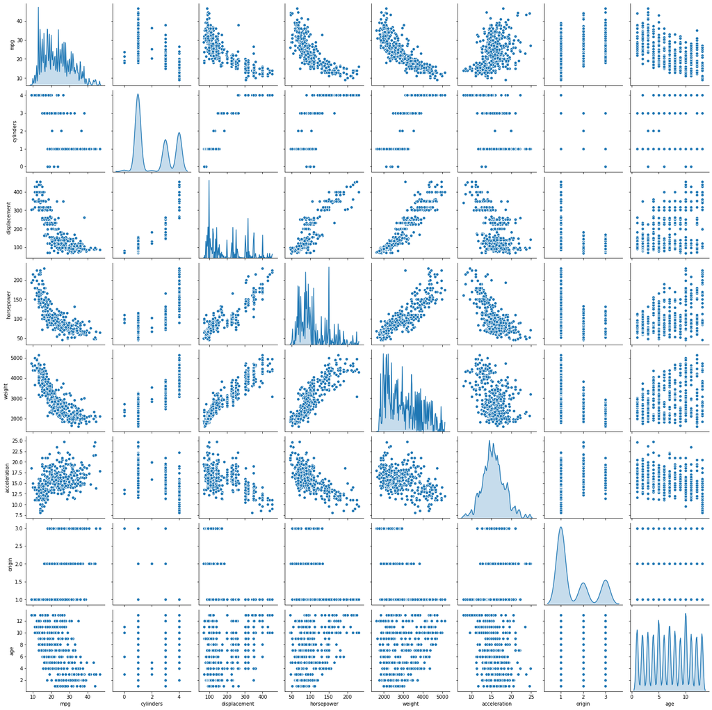

```python
sns.pairplot(df,diag_kind='kde',diag_kws={'bw': 0.2})
```

```python
df.drop('acceleration',axis=1,inplace=True)
```

**Based on the above distribution we can say three cluster is optimal for these data.**

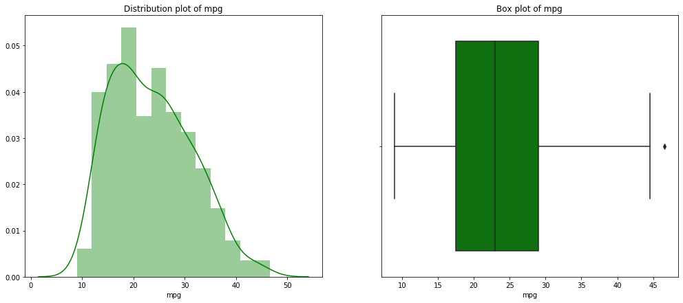

```
 Total Number of outliers in mpg: 1
```

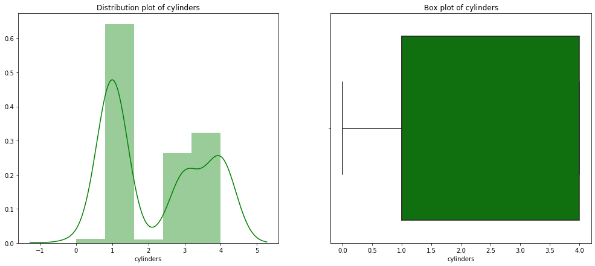

```
 Total Number of outliers in cylinders: 0
```

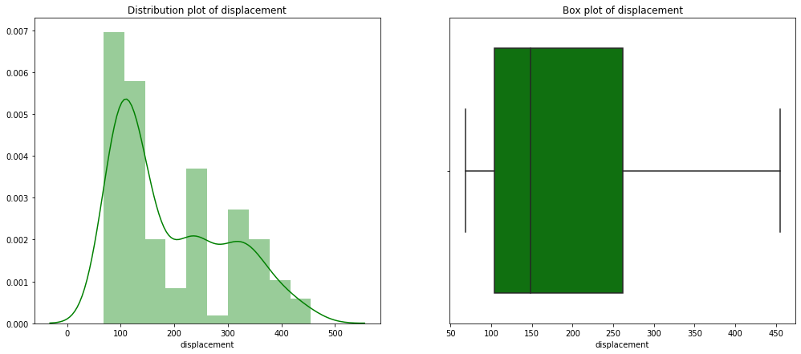

```
 Total Number of outliers in displacement: 0
```

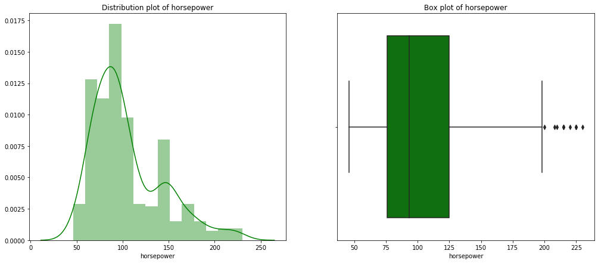

```
 Total Number of outliers in horsepower: 11
```

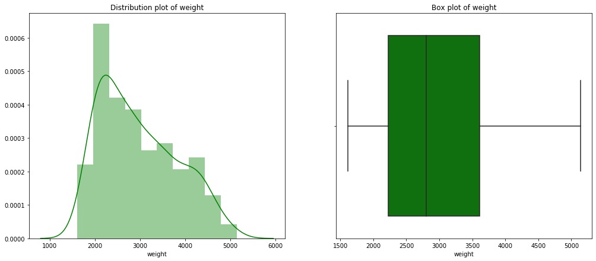

```
 Total Number of outliers in weight: 0
```

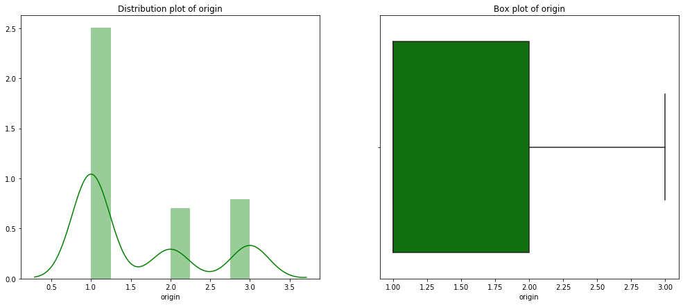

```
 Total Number of outliers in origin: 0
```

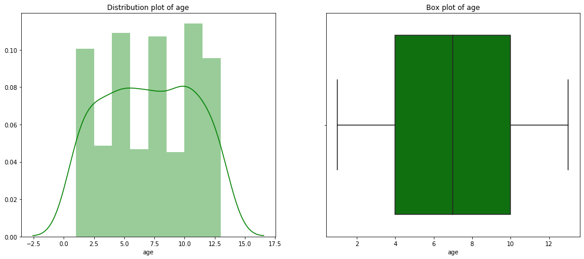

```
 Total Number of outliers in age: 0
```

```python
for i in df.select_dtypes(include=['int32','int64','float64','float32']).columns:
    f, axes = plt.subplots(1, 2, figsize=(17,7))
    sns.boxplot(x = i, data=df,  orient='h' , ax=axes[1],color="Green")
    #sns.set(axis_bgcolor='k')
    sns.distplot(df[i],  ax=axes[0],color='Green')
    axes[0].set_title('Distribution plot of {}'.format(i))
    axes[1].set_title('Box plot of {}'.format(i))
    plt.show()
    #checking count of outliers.
    q25,q75=np.percentile(df[i],25),np.percentile(df[i],75)
    IQR=q75-q25
    Threshold=IQR*1.5
    lower,upper=q25-Threshold,q75+Threshold
    Outliers=[i for i in df[i] if i < lower or i > upper]
    print('{} Total Number of outliers in {}: {}'.format('\033[1m',i,len(Outliers)))
```

**HorsePower, mpg has few outliers**

**We will logaritmic transform for horsepower,mpg to remove outliers**

```python
df['horsepower'] = np.log(df['horsepower'])
df['mpg'] = np.log(df['mpg'])
```

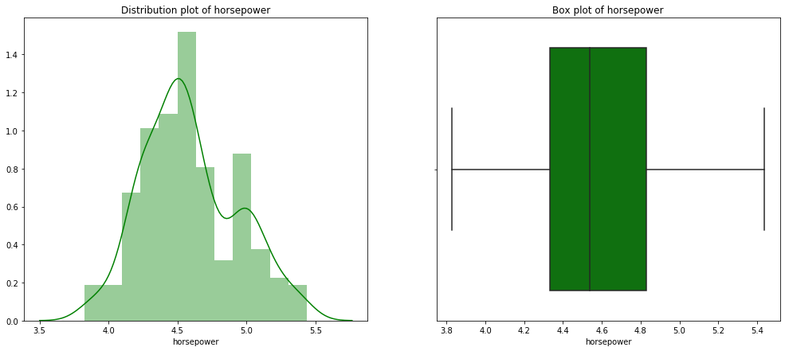

```
 Total Number of outliers in horsepower: 0
```

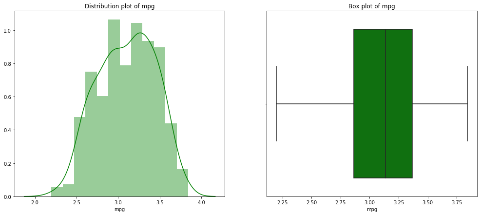

```
 Total Number of outliers in mpg: 0
```

```python
for i in ['horsepower','mpg']:
    f, axes = plt.subplots(1, 2, figsize=(17,7))
    sns.boxplot(x = i, data=df,  orient='h' , ax=axes[1],color="Green")
    #sns.set(axis_bgcolor='k')
    sns.distplot(df[i],  ax=axes[0],color='Green')
    axes[0].set_title('Distribution plot of {}'.format(i))
    axes[1].set_title('Box plot of {}'.format(i))
    plt.show()
    #checking count of outliers.
    q25,q75=np.percentile(df[i],25),np.percentile(df[i],75)
    IQR=q75-q25
    Threshold=IQR*1.5
    lower,upper=q25-Threshold,q75+Threshold
    Outliers=[i for i in df[i] if i < lower or i > upper]
    print('{} Total Number of outliers in {}: {}'.format('\033[1m',i,len(Outliers)))
```

**This looks better. We can see outliers has removed after log transformation**

**Correlation Plot**

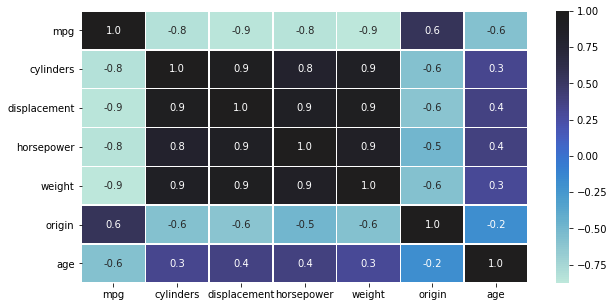

```python
plt.figure(figsize=(10,5))
sns.heatmap(df.corr(), annot=True, linewidths=.5, fmt= '.1f', center = 1 )  # heatmap
plt.show()
```

**We can see many independent variables are correlated to each other (i.e)There exists multi-collinearity**

**Getting Correlated Columns**

```python
data=df.drop('mpg',axis=1)
#Threshold for removing correlated variables
threshold = 0.9

# Absolute value correlation matrix
corr_matrix = data.corr().abs()
corr_matrix.head()

# Upper triangle of correlations
upper = corr_matrix.where(np.triu(np.ones(corr_matrix.shape), k=1).astype(np.bool))
upper.head()

# Select columns with correlations above threshold
to_drop = [column for column in upper.columns if any(upper[column] > threshold)]

print('There are %d columns to remove :' % (len(to_drop)))

#data = data.drop(columns = to_drop)

print(to_drop)
```

```
There are 2 columns to remove :
['displacement', 'weight']
```

# Step 4: Machine Learning

**Scaling**

```python
df_scaled=df.copy() #taking copy of existing dataframe
```

```python
df_scaled.drop(to_drop,axis=1,inplace=True) #dropping multi-collinear columns
```

```python
li=list(df_scaled.select_dtypes(include=['int64','float64']).columns)
print(li)
```

```
['mpg', 'cylinders', 'horsepower', 'origin', 'age']
```

```python
#li.remove('cylinders')
```

```python
df_scaled[li]=df_scaled[li].apply(zscore) #replacing rach continuos values with z-score value
```

```python
df_scaled.describe()
```

[output not shown]

**We can see after scaling S.D is 1 and Mean is 0**

# **K-Means Clustering**

```python
cluster_range = range( 2, 6 )   # expect 3 to four clusters from the pair panel visual inspection hence restricting from 2 to 6
cluster_errors = []
for num_clusters in cluster_range:
  clusters = KMeans( num_clusters,random_state=1)
  clusters.fit(df_scaled)
  labels = clusters.labels_
  centroids = clusters.cluster_centers_
  cluster_errors.append( clusters.inertia_ )
clusters_df = pd.DataFrame( { "num_clusters":cluster_range, "cluster_errors": cluster_errors } )
clusters_df
```

|  | num_clusters | cluster_errors |
| --- | --- | --- |
| 0 | 2 | 1192.740485 |
| 1 | 3 | 757.093228 |
| 2 | 4 | 614.597309 |
| 3 | 5 | 492.416508 |

**We can see when the clusters are increased the errors are decreased.**

**Building with 3 Clusters**

```python
model=KMeans(n_clusters=3,random_state=1)
```

```python
model.fit(df_scaled)
prediction=model.predict(df_scaled)
```

```python
print(prediction)
```

```
[2 2 2 2 2 2 2 2 2 2 2 2 2 2 1 2 2 2 1 1 1 1 1 1 2 2 2 2 2 1 0 1 0 2 2 2 2
 2 2 2 2 2 2 2 2 2 0 2 2 0 1 1 1 1 1 1 0 1 0 1 0 0 2 2 2 2 2 2 2 2 2 1 2 2
 2 2 1 1 1 1 0 1 1 0 1 2 2 2 2 2 2 2 2 2 2 2 2 2 2 2 2 2 1 2 2 2 2 2 1 0 1
 1 0 2 1 2 2 1 1 1 1 2 1 1 2 2 2 2 2 1 0 1 0 2 2 2 2 2 2 2 2 1 1 1 1 1 0 1
 1 1 1 1 2 2 2 2 2 2 2 2 2 2 2 2 2 2 2 1 0 2 0 1 1 1 2 1 2 1 1 1 1 1 1 1 0
 0 1 2 2 2 2 0 0 0 0 0 0 1 1 2 0 2 2 1 1 1 0 1 2 1 1 2 2 2 2 2 1 0 1 0 1 2
 2 2 2 2 0 2 2 2 2 2 2 1 0 1 0 0 0 1 1 1 1 1 1 0 1 1 1 2 2 2 0 0 0 0 0 0 0
 0 2 2 2 2 2 2 0 1 1 0 1 0 0 1 0 2 0 2 1 1 0 0 0 0 0 2 2 2 2 2 2 2 2 1 1 0
 0 1 2 1 0 0 0 1 1 0 0 0 0 1 1 0 1 0 0 0 0 1 1 1 1 1 1 0 1 1 1 1 1 1 1 1 1
 1 1 1 0 1 0 0 0 0 0 1 0 1 1 1 1 1 0 0 0 1 1 1 1 1 1 1 0 1 1 0 0 0 0 0 0 0
 0 0 0 0 0 1 1 1 0 0 1 1 1 1 1 1 0 0 0 0 1 0 0 0 1 0 0 0]
```

**We can see our model has predicted the data into three clusters**

**Finding optimal no. of clusters using Elbow Method**

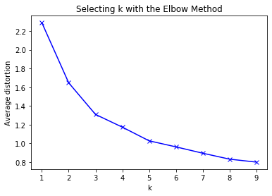

```python
#Finding optimal no. of clusters
from scipy.spatial.distance import cdist
clusters=range(1,10)
meanDistortions=[]

for k in clusters:
    model=KMeans(n_clusters=k,random_state=1)
    model.fit(df_scaled)
    prediction=model.predict(df_scaled)
    meanDistortions.append(sum(np.min(cdist(df_scaled, model.cluster_centers_, 'euclidean'), axis=1)) / df_scaled.shape[0])


plt.plot(clusters, meanDistortions, 'bx-')
plt.xlabel('k')
plt.ylabel('Average distortion')
plt.title('Selecting k with the Elbow Method')
```

**We can see 3 and 5 are clusters are correct for this data. Both seems to be optimum number of clusters.**

**Since our EDA suggests there are three distributions of data we will go on with 3 clusters.**

# Final Kmeans

**3 Clusters**

```python
final_model=KMeans(3,random_state=1)
final_model.fit(df_scaled)
prediction=final_model.predict(df_scaled)

#Append the prediction
df["GROUP"] = prediction
df_scaled["GROUP"] = prediction
```

**Checking the number of data in each cluster**

```python
labels = final_model.labels_
counts = np.bincount(labels[labels>=0])
print(counts)
```

```
[104 143 151]
```

**Distribution looks fine**

```python
df_Clust = df.groupby(['GROUP'])
df_Clust.mean() #taking  mean for each cluster
```

| GROUP | mpg | cylinders | displacement | horsepower | weight | origin | age |
| --- | --- | --- | --- | --- | --- | --- | --- |
| 0 | 3.24733 | 1.605769 | 152.168269 | 4.448282 | 2661.817308 | 1.028846 | 4.711538 |
| 1 | 3.36602 | 1.069930 | 103.937063 | 4.345118 | 2279.391608 | 2.552448 | 6.384615 |
| 2 | 2.75025 | 3.668874 | 306.589404 | 4.912077 | 3837.397351 | 1.019868 | 9.132450 |

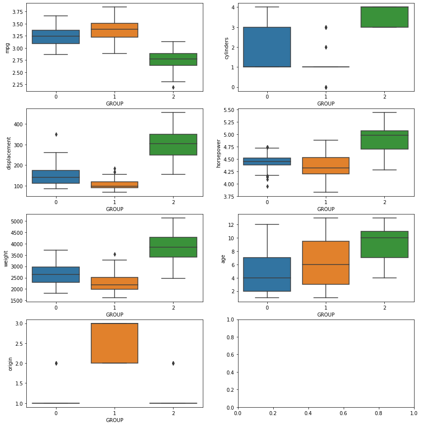

```python
f, axes = plt.subplots(4, 2, figsize=(14,15))
sns.boxplot(x='GROUP',y='mpg',data=df,ax=axes[0][0])
sns.boxplot(x='GROUP',y='cylinders',data=df,ax=axes[0][1])
sns.boxplot(x='GROUP',y='displacement',data=df,ax=axes[1][0])
sns.boxplot(x='GROUP',y='horsepower',data=df,ax=axes[1][1])
sns.boxplot(x='GROUP',y='weight',data=df,ax=axes[2][0])
#sns.boxplot(x='GROUP',y='acceleration',data=df,ax=axes[2][1])
sns.boxplot(x='GROUP',y='age',data=df,ax=axes[2][1])
sns.boxplot(x='GROUP',y='origin',data=df,ax=axes[3][0])
#sns.boxplot(x='GROUP',y='origin_2',data=df,ax=axes[3][1])
#sns.boxplot(x='GROUP',y='origin_3',data=df,ax=axes[4][0])
plt.show()
```

- **We can see mpg with maximum value,minimum value and medium values are assigned to each seperate clusters.**
- **Cluster with highest mpg value has less horsepower,displacement and weight**
- **Similarly Cluster with less mpg has high horsepower,weight and displacement. This cluster belongs to high end cars . obviously when power is more mpg will be less.**
- **We can see few outliers as well in some columns**

**Silhouette Score.**

```python
print(silhouette_score(df_scaled, prediction, metric='euclidean'))
```

```
0.4295049726066449
```

**Analyzing MPG column with other variables.**

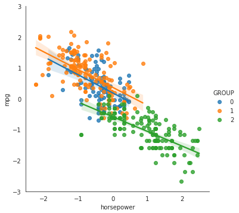

```python
#MPG vs Horsepower

var = 'horsepower'

with sns.axes_style("white"):
    plot = sns.lmplot(var,'mpg',data=df_scaled,hue='GROUP')
plot.set(ylim = (-3,3))
```

- **We can see Horse power variable is effective to low end , high end and medium cars.**
- **It is effective for cluster which have higher mpg.**
- **We can also see horsepower is totally different for high and low end cars.**

**Creating seperate dataset for each cluster.**

```python
df_Kmeans_cluster1=df_scaled[df_scaled['GROUP']==0]
df_Kmenas_cluster2=df_scaled[df_scaled['GROUP']==1]
df_Kmeans_cluster3=df_scaled[df_scaled['GROUP']==2]
```

```python
df_scaled_F=df_scaled.copy()
df_1=df.copy()
```

```python
final_model_F=KMeans(4,random_state=1)
final_model_F.fit(df_scaled)
prediction_F=final_model_F.predict(df_scaled)

#Append the prediction
df_1["GROUP"] = prediction_F
df_scaled_F["GROUP"] = prediction_F
print("Groups Assigned : \n")
df_1.head()
```

```
Groups Assigned :
```

|  | mpg | cylinders | displacement | horsepower | weight | origin | age | GROUP |
| --- | --- | --- | --- | --- | --- | --- | --- | --- |
| 0 | 2.890372 | 4 | 307.0 | 4.867534 | 3504 | 1 | 13 | 1 |
| 1 | 2.708050 | 4 | 350.0 | 5.105945 | 3693 | 1 | 13 | 1 |
| 2 | 2.890372 | 4 | 318.0 | 5.010635 | 3436 | 1 | 13 | 1 |
| 3 | 2.772589 | 4 | 304.0 | 5.010635 | 3433 | 1 | 13 | 1 |
| 4 | 2.833213 | 4 | 302.0 | 4.941642 | 3449 | 1 | 13 | 1 |

```python
labels_F = final_model_F.labels_
counts_F = np.bincount(labels_F[labels_F>=0])
print(counts_F)
```

```
[ 75 151  92  80]
```

**Distribution of two clusters are nearly equal**

```python
df_Clust_1 = df_1.groupby(['GROUP'])
df_Clust_1.mean() #taking  mean for each cluster
```

| GROUP | mpg | cylinders | displacement | horsepower | weight | origin | age |
| --- | --- | --- | --- | --- | --- | --- | --- |
| 0 | 3.192959 | 1.013333 | 107.020000 | 4.426257 | 2330.346667 | 2.133333 | 10.066667 |
| 1 | 2.750250 | 3.668874 | 306.589404 | 4.912077 | 3837.397351 | 1.019868 | 9.132450 |
| 2 | 3.261036 | 1.684783 | 156.445652 | 4.453394 | 2716.369565 | 1.032609 | 3.858696 |
| 3 | 3.494700 | 1.112500 | 103.362500 | 4.278646 | 2226.250000 | 2.712500 | 3.662500 |

**We can see there is very less difference in each group.**

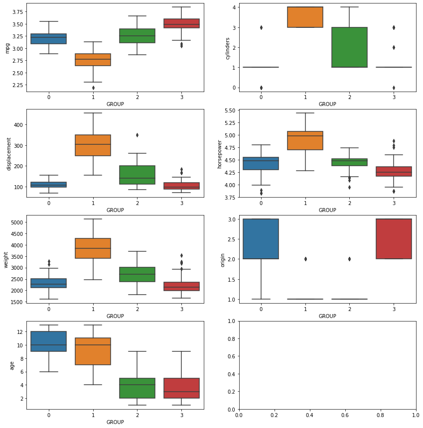

```python
f, axes = plt.subplots(4, 2, figsize=(14,15))
sns.boxplot(x='GROUP',y='mpg',data=df_1,ax=axes[0][0])
sns.boxplot(x='GROUP',y='cylinders',data=df_1,ax=axes[0][1])
sns.boxplot(x='GROUP',y='displacement',data=df_1,ax=axes[1][0])
sns.boxplot(x='GROUP',y='horsepower',data=df_1,ax=axes[1][1])
sns.boxplot(x='GROUP',y='weight',data=df_1,ax=axes[2][0])
sns.boxplot(x='GROUP',y='origin',data=df_1,ax=axes[2][1])
sns.boxplot(x='GROUP',y='age',data=df_1,ax=axes[3][0])
#sns.boxplot(x='GROUP',y='origin',data=df,ax=axes[3][1])
plt.show()
```

**It is evident that two clusters nearly have similar values. Distribution is similiar in these cluster.**

**We can select optimal cluster as 3 instead of 4.**

# Hierarchical Clustering.

```python
df_scaled.columns
```

```
Index(['mpg', 'cylinders', 'horsepower', 'origin', 'age', 'GROUP'], dtype='object')
```

```python
df_hier=df_scaled.copy()
```

**Agglomerative Cluster**

```python
model_hier = AgglomerativeClustering(n_clusters=3, affinity='euclidean',  linkage='average')
model_hier.fit(df_hier)
```

```
AgglomerativeClustering(linkage='average', n_clusters=3)
```

```python
df_hier['GROUP_HIER'] = model_hier.labels_
df_hier.head(5)
```

|  | mpg | cylinders | horsepower | origin | age | GROUP | GROUP_HIER |
| --- | --- | --- | --- | --- | --- | --- | --- |
| 0 | -0.622035 | 1.359605 | 0.823608 | -0.715145 | 1.627426 | 2 | 1 |
| 1 | -1.159493 | 1.359605 | 1.523992 | -0.715145 | 1.627426 | 2 | 1 |
| 2 | -0.622035 | 1.359605 | 1.243998 | -0.715145 | 1.627426 | 2 | 1 |
| 3 | -0.969242 | 1.359605 | 1.243998 | -0.715145 | 1.627426 | 2 | 1 |
| 4 | -0.790530 | 1.359605 | 1.041316 | -0.715145 | 1.627426 | 2 | 1 |

```python
df_hier.drop(['GROUP'],axis=1,inplace=True)
```

```python
df_scaled_Hierclustr = df_hier.groupby(['GROUP_HIER'])
```

**Mean of values in each clusters**

```python
df_scaled_Hierclustr.mean()
```

| GROUP_HIER | mpg | cylinders | horsepower | origin | age |
| --- | --- | --- | --- | --- | --- |
| 0 | 0.766920 | -0.844180 | -0.697137 | 1.213367 | -0.169086 |
| 1 | -1.035094 | 1.110051 | 0.954462 | -0.690343 | 0.580155 |
| 2 | 0.442116 | -0.443251 | -0.421950 | -0.702906 | -0.618489 |

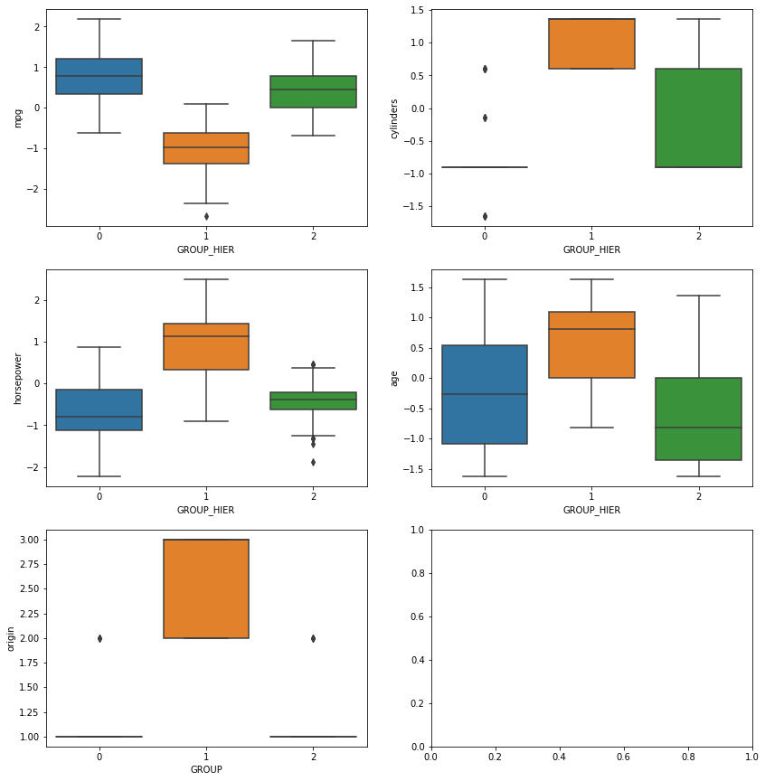

```python
f, axes = plt.subplots(3, 2, figsize=(14,15))
sns.boxplot(x='GROUP_HIER',y='mpg',data=df_hier,ax=axes[0][0])
sns.boxplot(x='GROUP_HIER',y='cylinders',data=df_hier,ax=axes[0][1])
#sns.boxplot(x='GROUP_HIER',y='displacement',data=df_hier,ax=axes[0][1])
sns.boxplot(x='GROUP_HIER',y='horsepower',data=df_hier,ax=axes[1][0])
#sns.boxplot(x='GROUP_HIER',y='weight',data=df_hier,ax=axes[1][1])
#sns.boxplot(x='GROUP_HIER',y='acceleration',data=df_hier,ax=axes[2][0])
sns.boxplot(x='GROUP_HIER',y='age',data=df_hier,ax=axes[1][1])
sns.boxplot(x='GROUP',y='origin',data=df,ax=axes[2][0])
plt.show()
```

- **Hierarchical clusters behaves similarly like K-means.**
- **Cluster with highest mpg value has less horsepower**
- **Similarly Cluster with less mpg has high horsepower. This cluster belongs to high end cars . obviously when power is more mpg will be less.**

**Average Linkage Method**

```python
Z = linkage(df_hier, metric='euclidean', method='average')
c, coph_dists = cophenet(Z , pdist(df_hier))
print(c)
```

```
0.7835838679651829
```

**Dendogram**

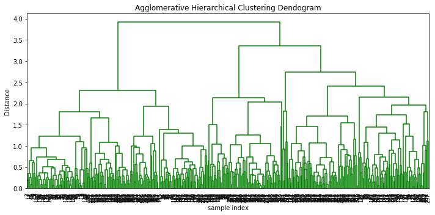

```python
plt.figure(figsize=(10, 5))
plt.title('Agglomerative Hierarchical Clustering Dendogram')
plt.xlabel('sample index')
plt.ylabel('Distance')
dendrogram(Z, leaf_rotation=90.,color_threshold = 40, leaf_font_size=8. )
plt.tight_layout()
```

- **Dendogram indicates that we can go on with three clusters.**
- **Cophenet index is a measure of the correlation between the distance of points in feature space and distance on dendrogram,closer it is to 1, the better is the clustering**
- **We will get different dendograms based on distance measure between the cluster so we can choose the best distance method based on cophenet index.**

**Complete linkage method**

```
0.7347443272001688
```

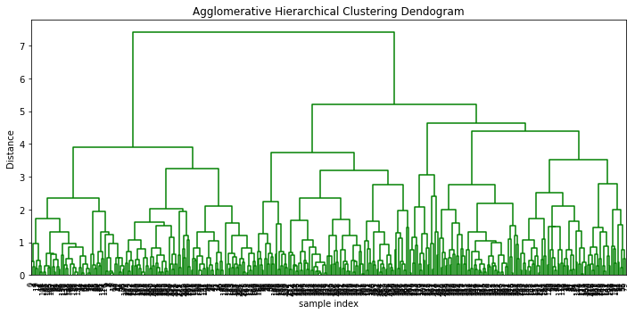

```python
Z = linkage(df_hier, metric='euclidean', method='complete')
c, coph_dists = cophenet(Z , pdist(df_hier))
print(c)
plt.figure(figsize=(10, 5))
plt.title('Agglomerative Hierarchical Clustering Dendogram')
plt.xlabel('sample index')
plt.ylabel('Distance')
dendrogram(Z, leaf_rotation=90.,color_threshold = 40, leaf_font_size=8. )
plt.tight_layout()
```

**Cophenet index is less compared to average method.**

**Ward Method**

```
0.7506278810963883
```

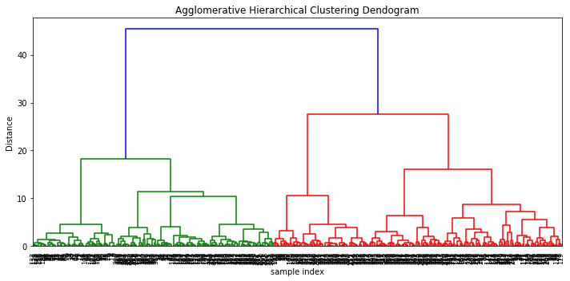

```python
Z = linkage(df_hier, metric='euclidean', method='ward')
c, coph_dists = cophenet(Z , pdist(df_hier))
print(c)
plt.figure(figsize=(10, 5))
plt.title('Agglomerative Hierarchical Clustering Dendogram')
plt.xlabel('sample index')
plt.ylabel('Distance')
dendrogram(Z, leaf_rotation=90.,color_threshold = 40, leaf_font_size=8. )
plt.tight_layout()
```

**Cophenet index is slightly better than complete linkage method**

**Final Dendogram**

```python
Z = linkage(df_hier, metric='euclidean', method='average')
```

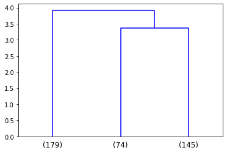

```python
# Hint: Use truncate_mode='lastp' attribute in dendrogram function to arrive at dendrogram
dendrogram(
    Z,
    truncate_mode='lastp',  # show only the last p merged clusters
    p=3,  # show only the last p merged clusters
)
plt.show()
```

```python
df_hier_cluster1=df_hier[df_hier['GROUP_HIER']==0]
df_hier_cluster2=df_hier[df_hier['GROUP_HIER']==1]
df_hier_cluster3=df_hier[df_hier['GROUP_HIER']==2]
```